# QStyle Class

The QStyle class is an abstract base class that encapsulates the look and feel of a GUI. More...

| Header: | `#include <QStyle>` |
| --- | --- |
| CMake: | `find_package(Qt6 REQUIRED COMPONENTS Widgets)` `target_link_libraries(mytarget PRIVATE Qt6::Widgets)` |
| qmake: | `QT += widgets` |
| Inherits: | QObject |
| Inherited By: | QCommonStyle |

- [List of all members, including inherited members](https://doc.qt.io/qt-6.9/qstyle-members.html)
- [Deprecated members](https://doc.qt.io/qt-6.9/qstyle-obsolete.html)

## Public Types

| enum | **ComplexControl** { CC_SpinBox, CC_ComboBox, CC_ScrollBar, CC_Slider, CC_ToolButton, …, CC_CustomBase } |
| --- | --- |
| enum | **ContentsType** { CT_CheckBox, CT_ComboBox, CT_HeaderSection, CT_LineEdit, CT_Menu, …, CT_MdiControls } |
| enum | **ControlElement** { CE_PushButton, CE_PushButtonBevel, CE_PushButtonLabel, CE_DockWidgetTitle, CE_Splitter, …, CE_ShapedFrame } |
| enum | **PixelMetric** { PM_ButtonMargin, PM_DockWidgetTitleBarButtonMargin, PM_ButtonDefaultIndicator, PM_MenuButtonIndicator, PM_ButtonShiftHorizontal, …, PM_CustomBase } |
| enum | **PrimitiveElement** { PE_PanelButtonCommand, PE_FrameDefaultButton, PE_PanelButtonBevel, PE_PanelButtonTool, PE_PanelLineEdit, …, PE_PanelMenu } |
| enum | **RequestSoftwareInputPanel** { RSIP_OnMouseClickAndAlreadyFocused, RSIP_OnMouseClick } |
| enum | **StandardPixmap** { SP_TitleBarMinButton, SP_TitleBarMenuButton, SP_TitleBarMaxButton, SP_TitleBarCloseButton, SP_TitleBarNormalButton, …, SP_CustomBase } |
| flags | **State** |
| enum | **StateFlag** { State_None, State_Active, State_AutoRaise, State_Children, State_DownArrow, …, State_Small } |
| enum | **StyleHint** { SH_EtchDisabledText, SH_DitherDisabledText, SH_ScrollBar_ContextMenu, SH_ScrollBar_MiddleClickAbsolutePosition, SH_ScrollBar_LeftClickAbsolutePosition, …, SH_Table_AlwaysDrawLeftTopGri… |
| enum | **SubControl** { SC_None, SC_ScrollBarAddLine, SC_ScrollBarSubLine, SC_ScrollBarAddPage, SC_ScrollBarSubPage, …, SC_All } |
| flags | **SubControls** |
| enum | **SubElement** { SE_PushButtonContents, SE_PushButtonFocusRect, SE_PushButtonLayoutItem, SE_PushButtonBevel, SE_CheckBoxIndicator, …, SE_ToolBarHandle } |

## Public Functions

|  | **QStyle**() |
| --- | --- |
| virtual | **~QStyle**() |
| int | **combinedLayoutSpacing**(QSizePolicy::ControlTypes *controls1*, QSizePolicy::ControlTypes *controls2*, Qt::Orientation *orientation*, QStyleOption **option* = nullptr, QWidget **widget* = nullptr) co… |
| virtual void | **drawComplexControl**(QStyle::ComplexControl *control*, const QStyleOptionComplex **option*, QPainter **painter*, const QWidget **widget* = nullptr) const = 0 |
| virtual void | **drawControl**(QStyle::ControlElement *element*, const QStyleOption **option*, QPainter **painter*, const QWidget **widget* = nullptr) const = 0 |
| virtual void | **drawItemPixmap**(QPainter **painter*, const QRect &*rectangle*, int *alignment*, const QPixmap &*pixmap*) const |
| virtual void | **drawItemText**(QPainter **painter*, const QRect &*rectangle*, int *alignment*, const QPalette &*palette*, bool *enabled*, const QString &*text*, QPalette::ColorRole *textRole* = QPalette::NoRole) co… |
| virtual void | **drawPrimitive**(QStyle::PrimitiveElement *element*, const QStyleOption **option*, QPainter **painter*, const QWidget **widget* = nullptr) const = 0 |
| virtual QPixmap | **generatedIconPixmap**(QIcon::Mode *iconMode*, const QPixmap &*pixmap*, const QStyleOption **option*) const = 0 |
| virtual QStyle::SubControl | **hitTestComplexControl**(QStyle::ComplexControl *control*, const QStyleOptionComplex **option*, const QPoint &*position*, const QWidget **widget* = nullptr) const = 0 |
| virtual QRect | **itemPixmapRect**(const QRect &*rectangle*, int *alignment*, const QPixmap &*pixmap*) const |
| virtual QRect | **itemTextRect**(const QFontMetrics &*metrics*, const QRect &*rectangle*, int *alignment*, bool *enabled*, const QString &*text*) const |
| virtual int | **layoutSpacing**(QSizePolicy::ControlType *control1*, QSizePolicy::ControlType *control2*, Qt::Orientation *orientation*, const QStyleOption **option* = nullptr, const QWidget **widget* = nullptr) co… |
| `(since 6.1)` QString | **name**() const |
| virtual int | **pixelMetric**(QStyle::PixelMetric *metric*, const QStyleOption **option* = nullptr, const QWidget **widget* = nullptr) const = 0 |
| virtual void | **polish**(QWidget **widget*) |
| virtual void | **polish**(QApplication **application*) |
| virtual void | **polish**(QPalette &*palette*) |
| const QStyle * | **proxy**() const |
| virtual QSize | **sizeFromContents**(QStyle::ContentsType *type*, const QStyleOption **option*, const QSize &*contentsSize*, const QWidget **widget* = nullptr) const = 0 |
| virtual QIcon | **standardIcon**(QStyle::StandardPixmap *standardIcon*, const QStyleOption **option* = nullptr, const QWidget **widget* = nullptr) const = 0 |
| virtual QPalette | **standardPalette**() const |
| virtual int | **styleHint**(QStyle::StyleHint *hint*, const QStyleOption **option* = nullptr, const QWidget **widget* = nullptr, QStyleHintReturn **returnData* = nullptr) const = 0 |
| virtual QRect | **subControlRect**(QStyle::ComplexControl *control*, const QStyleOptionComplex **option*, QStyle::SubControl *subControl*, const QWidget **widget* = nullptr) const = 0 |
| virtual QRect | **subElementRect**(QStyle::SubElement *element*, const QStyleOption **option*, const QWidget **widget* = nullptr) const = 0 |
| virtual void | **unpolish**(QWidget **widget*) |
| virtual void | **unpolish**(QApplication **application*) |

## Static Public Members

| QRect | **alignedRect**(Qt::LayoutDirection *direction*, Qt::Alignment *alignment*, const QSize &*size*, const QRect &*rectangle*) |
| --- | --- |
| int | **sliderPositionFromValue**(int *min*, int *max*, int *logicalValue*, int *span*, bool *upsideDown* = false) |
| int | **sliderValueFromPosition**(int *min*, int *max*, int *position*, int *span*, bool *upsideDown* = false) |
| Qt::Alignment | **visualAlignment**(Qt::LayoutDirection *direction*, Qt::Alignment *alignment*) |
| QPoint | **visualPos**(Qt::LayoutDirection *direction*, const QRect &*boundingRectangle*, const QPoint &*logicalPosition*) |
| QRect | **visualRect**(Qt::LayoutDirection *direction*, const QRect &*boundingRectangle*, const QRect &*logicalRectangle*) |

## Detailed Description

Qt contains a set of QStyle subclasses that emulate the styles of the different platforms supported by Qt (QWindowsStyle, QMacStyle etc.). By default, these styles are built into the Qt GUI module. Styles can also be made available as plugins.

Qt's built-in widgets use QStyle to perform nearly all of their drawing, ensuring that they look exactly like the equivalent native widgets. The diagram below shows a QComboBox in nine different styles.

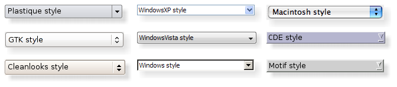

Topics:

### Setting a Style

The style of the entire application can be set using the QApplication::setStyle() function. It can also be specified by the user of the application, using the `-style` command-line option:

```
./myapplication -style windows
```

If no style is specified, Qt will choose the most appropriate style for the user's platform or desktop environment.

A style can also be set on an individual widget using the QWidget::setStyle() function.

### Developing Style-Aware Custom Widgets

If you are developing custom widgets and want them to look good on all platforms, you can use QStyle functions to perform parts of the widget drawing, such as drawItemText(), drawItemPixmap(), drawPrimitive(), drawControl(), and drawComplexControl().

Most QStyle draw functions take four arguments:

- an enum value specifying which graphical element to draw
- a QStyleOption specifying how and where to render that element
- a QPainter that should be used to draw the element
- a QWidget on which the drawing is performed (optional)

For example, if you want to draw a focus rectangle on your widget, you can write:

```
void MyWidget::paintEvent(QPaintEvent * /* event */)
{
    QPainter painter(this);

    QStyleOptionFocusRect option;
    option.initFrom(this);
    option.backgroundColor = palette().color(QPalette::Background);

    style()->drawPrimitive(QStyle::PE_FrameFocusRect, &option, &painter, this);
}
```

QStyle gets all the information it needs to render the graphical element from QStyleOption. The widget is passed as the last argument in case the style needs it to perform special effects (such as animated default buttons on macOS), but it isn't mandatory. In fact, you can use QStyle to draw on any paint device, not just widgets, by setting the QPainter properly.

QStyleOption has various subclasses for the various types of graphical elements that can be drawn. For example, PE_FrameFocusRect expects a QStyleOptionFocusRect argument.

To ensure that drawing operations are as fast as possible, QStyleOption and its subclasses have public data members. See the QStyleOption class documentation for details on how to use it.

For convenience, Qt provides the QStylePainter class, which combines a QStyle, a QPainter, and a QWidget. This makes it possible to write

```
    QStylePainter painter(this);
    ...
    painter.drawPrimitive(QStyle::PE_FrameFocusRect, option);
```

instead of

```
    QPainter painter(this);
    ...
    style()->drawPrimitive(QStyle::PE_FrameFocusRect, &option, &painter, this);
```

### Creating a Custom Style

You can create a custom look and feel for your application by creating a custom style. There are two approaches to creating a custom style. In the static approach, you either choose an existing QStyle class, subclass it, and reimplement virtual functions to provide the custom behavior, or you create an entire QStyle class from scratch. In the dynamic approach, you modify the behavior of your system style at runtime. The static approach is described below. The dynamic approach is described in QProxyStyle.

The first step in the static approach is to pick one of the styles provided by Qt from which you will build your custom style. Your choice of QStyle class will depend on which style resembles your desired style the most. The most general class that you can use as a base is QCommonStyle (not QStyle). This is because Qt requires its styles to be QCommonStyles.

Depending on which parts of the base style you want to change, you must reimplement the functions that are used to draw those parts of the interface. To illustrate this, we will modify the look of the spin box arrows drawn by QWindowsStyle. The arrows are *primitive elements* that are drawn by the drawPrimitive() function, so we need to reimplement that function. We need the following class declaration:

```
class CustomStyle : public QProxyStyle
{
    Q_OBJECT

public:
    CustomStyle(const QWidget *widget);
    ~CustomStyle() {}

    void drawPrimitive(PrimitiveElement element, const QStyleOption *option,
                       QPainter *painter, const QWidget *widget) const override;
};
```

To draw its up and down arrows, QSpinBox uses the PE_IndicatorSpinUp and PE_IndicatorSpinDown primitive elements. Here's how to reimplement the drawPrimitive() function to draw them differently:

```
void CustomStyle::drawPrimitive(PrimitiveElement element, const QStyleOption *option,
                                QPainter *painter, const QWidget *widget) const
{
    if (element == PE_IndicatorSpinUp || element == PE_IndicatorSpinDown) {
        QPolygon points(3);
        int x = option->rect.x();
        int y = option->rect.y();
        int w = option->rect.width() / 2;
        int h = option->rect.height() / 2;
        x += (option->rect.width() - w) / 2;
        y += (option->rect.height() - h) / 2;

        if (element == PE_IndicatorSpinUp) {
            points[0] = QPoint(x, y + h);
            points[1] = QPoint(x + w, y + h);
            points[2] = QPoint(x + w / 2, y);
        } else { // PE_SpinBoxDown
            points[0] = QPoint(x, y);
            points[1] = QPoint(x + w, y);
            points[2] = QPoint(x + w / 2, y + h);
        }

        if (option->state & State_Enabled) {
            painter->setPen(option->palette.mid().color());
            painter->setBrush(option->palette.buttonText());
        } else {
            painter->setPen(option->palette.buttonText().color());
            painter->setBrush(option->palette.mid());
        }
        painter->drawPolygon(points);
    } else {
        QProxyStyle::drawPrimitive(element, option, painter, widget);
    }
}
```

Notice that we don't use the `widget` argument, except to pass it on to the QWindowStyle::drawPrimitive() function. As mentioned earlier, the information about what is to be drawn and how it should be drawn is specified by a QStyleOption object, so there is no need to ask the widget.

If you need to use the `widget` argument to obtain additional information, be careful to ensure that it isn't 0 and that it is of the correct type before using it. For example:

```
    const QSpinBox *spinBox = qobject_cast<const QSpinBox *>(widget);
    if (spinBox) {
    ...
    }
```

When implementing a custom style, you cannot assume that the widget is a QSpinBox just because the enum value is called PE_IndicatorSpinUp or PE_IndicatorSpinDown.

**Warning:** Qt style sheets are currently not supported for custom QStyle subclasses. We plan to address this in some future release.

### Using a Custom Style

There are several ways of using a custom style in a Qt application. The simplest way is to pass the custom style to the QApplication::setStyle() static function before creating the QApplication object:

```
#include <QtWidgets>

#include "customstyle.h"

int main(int argc, char *argv[])
{
    QApplication::setStyle(new CustomStyle);
    QApplication app(argc, argv);
    QSpinBox spinBox;
    spinBox.show();
    return app.exec();
}
```

You can call QApplication::setStyle() at any time, but by calling it before the constructor, you ensure that the user's preference, set using the `-style` command-line option, is respected.

You may want to make your custom style available for use in other applications, which may not be yours and hence not available for you to recompile. The Qt Plugin system makes it possible to create styles as plugins. Styles created as plugins are loaded as shared objects at runtime by Qt itself. Please refer to the Qt Plugin documentation for more information on how to go about creating a style plugin.

Compile your plugin and put it into Qt's `plugins/styles` directory. We now have a pluggable style that Qt can load automatically. To use your new style with existing applications, simply start the application with the following argument:

```
./myapplication -style custom
```

The application will use the look and feel from the custom style you implemented.

### Right-to-Left Desktops

Languages written from right to left (such as Arabic and Hebrew) usually also mirror the whole layout of widgets, and require the light to come from the screen's top-right corner instead of top-left.

If you create a custom style, you should take special care when drawing asymmetric elements to make sure that they also look correct in a mirrored layout. An easy way to test your styles is to run applications with the `-reverse` command-line option or to call QApplication::setLayoutDirection() in your `main()` function.

Here are some things to keep in mind when making a style work well in a right-to-left environment:

- subControlRect() and subElementRect() return rectangles in screen coordinates
- QStyleOption::direction indicates in which direction the item should be drawn in
- If a style is not right-to-left aware it will display items as if it were left-to-right
- visualRect(), visualPos(), and visualAlignment() are helpful functions that will translate from logical to screen representations.
- alignedRect() will return a logical rect aligned for the current direction

### Styles in Item Views

The painting of items in views is performed by a delegate. Qt's default delegate, QStyledItemDelegate, is also used for calculating bounding rectangles of items, and their sub-elements for the various kind of item data roles QStyledItemDelegate supports. See the QStyledItemDelegate class description to find out which datatypes and roles are supported. You can read more about item data roles in Model/View Programming.

When QStyledItemDelegate paints its items, it draws CE_ItemViewItem, and calculates their size with CT_ItemViewItem. Note also that it uses SE_ItemViewItemText to set the size of editors. When implementing a style to customize drawing of item views, you need to check the implementation of QCommonStyle (and any other subclasses from which your style inherits). This way, you find out which and how other style elements are painted, and you can then reimplement the painting of elements that should be drawn differently.

We include a small example where we customize the drawing of item backgrounds.

```
    switch (element) {
        case (PE_PanelItemViewItem): {
            painter->save();

            QPoint topLeft = option->rect.topLeft();
            QPoint bottomRight = option->rect.topRight();
            QLinearGradient backgroundGradient(topLeft, bottomRight);
            backgroundGradient.setColorAt(0.0, QColor(Qt::yellow).lighter(190));
            backgroundGradient.setColorAt(1.0, Qt::white);
            painter->fillRect(option->rect, QBrush(backgroundGradient));

            painter->restore();
        break;
        }
        default:
            QProxyStyle::drawPrimitive(element, option, painter, widget);
    }
```

The primitive element PE_PanelItemViewItem is responsible for painting the background of items, and is called from QCommonStyle's implementation of CE_ItemViewItem.

To add support for drawing of new datatypes and item data roles, it is necessary to create a custom delegate. But if you only need to support the datatypes implemented by the default delegate, a custom style does not need an accompanying delegate. The QStyledItemDelegate class description gives more information on custom delegates.

The drawing of item view headers is also done by the style, giving control over size of header items and row and column sizes.

**See also** QStyleOption, QStylePainter, Styles and Style Aware Widgets, QStyledItemDelegate, and Styling.

## Member Type Documentation

### enum QStyle::ComplexControl

This enum describes the available complex controls. Complex controls have different behavior depending upon where the user clicks on them or which keys are pressed.

| Constant | Value | Description |
| --- | --- | --- |
| `QStyle::CC_SpinBox` | `0` | A spinbox, like QSpinBox. |
| `QStyle::CC_ComboBox` | `1` | A combobox, like QComboBox. |
| `QStyle::CC_ScrollBar` | `2` | A scroll bar, like QScrollBar. |
| `QStyle::CC_Slider` | `3` | A slider, like QSlider. |
| `QStyle::CC_ToolButton` | `4` | A tool button, like QToolButton. |
| `QStyle::CC_TitleBar` | `5` | A Title bar, like those used in QMdiSubWindow. |
| `QStyle::CC_GroupBox` | `7` | A group box, like QGroupBox. |
| `QStyle::CC_Dial` | `6` | A dial, like QDial. |
| `QStyle::CC_MdiControls` | `8` | The minimize, close, and normal button in the menu bar for a maximized MDI subwindow. |
| `QStyle::CC_CustomBase` | `0xf0000000` | Base value for custom complex controls. Custom values must be greater than this value. |

**See also** SubControl and drawComplexControl().

### enum QStyle::ContentsType

This enum describes the available contents types. These are used to calculate sizes for the contents of various widgets.

| Constant | Value | Description |
| --- | --- | --- |
| `QStyle::CT_CheckBox` | `1` | A check box, like QCheckBox. |
| `QStyle::CT_ComboBox` | `4` | A combo box, like QComboBox. |
| `QStyle::CT_HeaderSection` | `19` | A header section, like QHeader. |
| `QStyle::CT_LineEdit` | `14` | A line edit, like QLineEdit. |
| `QStyle::CT_Menu` | `10` | A menu, like QMenu. |
| `QStyle::CT_MenuBar` | `9` | A menu bar, like QMenuBar. |
| `QStyle::CT_MenuBarItem` | `8` | A menu bar item, like the buttons in a QMenuBar. |
| `QStyle::CT_MenuItem` | `7` | A menu item, like QMenuItem. |
| `QStyle::CT_ProgressBar` | `6` | A progress bar, like QProgressBar. |
| `QStyle::CT_PushButton` | `0` | A push button, like QPushButton. |
| `QStyle::CT_RadioButton` | `2` | A radio button, like QRadioButton. |
| `QStyle::CT_SizeGrip` | `16` | A size grip, like QSizeGrip. |
| `QStyle::CT_Slider` | `12` | A slider, like QSlider. |
| `QStyle::CT_ScrollBar` | `13` | A scroll bar, like QScrollBar. |
| `QStyle::CT_SpinBox` | `15` | A spin box, like QSpinBox. |
| `QStyle::CT_Splitter` | `5` | A splitter, like QSplitter. |
| `QStyle::CT_TabBarTab` | `11` | A tab on a tab bar, like QTabBar. |
| `QStyle::CT_TabWidget` | `17` | A tab widget, like QTabWidget. |
| `QStyle::CT_ToolButton` | `3` | A tool button, like QToolButton. |
| `QStyle::CT_GroupBox` | `20` | A group box, like QGroupBox. |
| `QStyle::CT_ItemViewItem` | `22` | An item inside an item view. |
| `QStyle::CT_CustomBase` | `0xf0000000` | Base value for custom contents types. Custom values must be greater than this value. |
| `QStyle::CT_MdiControls` | `21` | The minimize, normal, and close button in the menu bar for a maximized MDI subwindow. |

**See also** sizeFromContents().

### enum QStyle::ControlElement

This enum represents a control element. A control element is a part of a widget that performs some action or displays information to the user.

| Constant | Value | Description |
| --- | --- | --- |
| `QStyle::CE_PushButton` | `0` | A QPushButton, draws CE_PushButtonBevel, CE_PushButtonLabel and PE_FrameFocusRect. |
| `QStyle::CE_PushButtonBevel` | `1` | The bevel and default indicator of a QPushButton. |
| `QStyle::CE_PushButtonLabel` | `2` | The label (an icon with text or pixmap) of a QPushButton. |
| `QStyle::CE_DockWidgetTitle` | `30` | Dock window title. |
| `QStyle::CE_Splitter` | `28` | Splitter handle; see also QSplitter. |
| `QStyle::CE_CheckBox` | `3` | A QCheckBox, draws a PE_IndicatorCheckBox, a CE_CheckBoxLabel and a PE_FrameFocusRect. |
| `QStyle::CE_CheckBoxLabel` | `4` | The label (text or pixmap) of a QCheckBox. |
| `QStyle::CE_RadioButton` | `5` | A QRadioButton, draws a PE_IndicatorRadioButton, a CE_RadioButtonLabel and a PE_FrameFocusRect. |
| `QStyle::CE_RadioButtonLabel` | `6` | The label (text or pixmap) of a QRadioButton. |
| `QStyle::CE_TabBarTab` | `7` | The tab and label within a QTabBar. |
| `QStyle::CE_TabBarTabShape` | `8` | The tab shape within a tab bar. |
| `QStyle::CE_TabBarTabLabel` | `9` | The label within a tab. |
| `QStyle::CE_ProgressBar` | `10` | A QProgressBar, draws CE_ProgressBarGroove, CE_ProgressBarContents and CE_ProgressBarLabel. |
| `QStyle::CE_ProgressBarGroove` | `11` | The groove where the progress indicator is drawn in a QProgressBar. |
| `QStyle::CE_ProgressBarContents` | `12` | The progress indicator of a QProgressBar. |
| `QStyle::CE_ProgressBarLabel` | `13` | The text label of a QProgressBar. |
| `QStyle::CE_ToolButtonLabel` | `22` | A tool button's label. |
| `QStyle::CE_MenuBarItem` | `20` | A menu item in a QMenuBar. |
| `QStyle::CE_MenuBarEmptyArea` | `21` | The empty area of a QMenuBar. |
| `QStyle::CE_MenuItem` | `14` | A menu item in a QMenu. |
| `QStyle::CE_MenuScroller` | `15` | Scrolling areas in a QMenu when the style supports scrolling. |
| `QStyle::CE_MenuTearoff` | `18` | A menu item representing the tear off section of a QMenu. |
| `QStyle::CE_MenuEmptyArea` | `19` | The area in a menu without menu items. |
| `QStyle::CE_MenuHMargin` | `17` | The horizontal extra space on the left/right of a menu. |
| `QStyle::CE_MenuVMargin` | `16` | The vertical extra space on the top/bottom of a menu. |
| `QStyle::CE_ToolBoxTab` | `26` | The toolbox's tab and label within a QToolBox. |
| `QStyle::CE_SizeGrip` | `27` | Window resize handle; see also QSizeGrip. |
| `QStyle::CE_Header` | `23` | A header. |
| `QStyle::CE_HeaderSection` | `24` | A header section. |
| `QStyle::CE_HeaderLabel` | `25` | The header's label. |
| `QStyle::CE_ScrollBarAddLine` | `31` | Scroll bar line increase indicator. (i.e., scroll down); see also QScrollBar. |
| `QStyle::CE_ScrollBarSubLine` | `32` | Scroll bar line decrease indicator (i.e., scroll up). |
| `QStyle::CE_ScrollBarAddPage` | `33` | Scolllbar page increase indicator (i.e., page down). |
| `QStyle::CE_ScrollBarSubPage` | `34` | Scroll bar page decrease indicator (i.e., page up). |
| `QStyle::CE_ScrollBarSlider` | `35` | Scroll bar slider. |
| `QStyle::CE_ScrollBarFirst` | `36` | Scroll bar first line indicator (i.e., home). |
| `QStyle::CE_ScrollBarLast` | `37` | Scroll bar last line indicator (i.e., end). |
| `QStyle::CE_RubberBand` | `29` | Rubber band used in for example an icon view. |
| `QStyle::CE_FocusFrame` | `38` | Focus frame that is style controlled. |
| `QStyle::CE_ItemViewItem` | `45` | An item inside an item view. |
| `QStyle::CE_CustomBase` | `0xf0000000` | Base value for custom control elements; custom values must be greater than this value. |
| `QStyle::CE_ComboBoxLabel` | `39` | The label of a non-editable QComboBox. |
| `QStyle::CE_ToolBar` | `40` | A toolbar like QToolBar. |
| `QStyle::CE_ToolBoxTabShape` | `41` | The toolbox's tab shape. |
| `QStyle::CE_ToolBoxTabLabel` | `42` | The toolbox's tab label. |
| `QStyle::CE_HeaderEmptyArea` | `43` | The area of a header view where there are no header sections. |
| `QStyle::CE_ShapedFrame` | `46` | The frame with the shape specified in the QStyleOptionFrame; see QFrame. |

**See also** drawControl().

### enum QStyle::PixelMetric

This enum describes the various available pixel metrics. A pixel metric is a style dependent size represented by a single pixel value.

| Constant | Value | Description |
| --- | --- | --- |
| `QStyle::PM_ButtonMargin` | `0` | Amount of whitespace between push button labels and the frame. |
| `QStyle::PM_DockWidgetTitleBarButtonMargin` | `73` | Amount of whitespace between dock widget's title bar button labels and the frame. |
| `QStyle::PM_ButtonDefaultIndicator` | `1` | Width of the default-button indicator frame. |
| `QStyle::PM_MenuButtonIndicator` | `2` | Width of the menu button indicator proportional to the widget height. |
| `QStyle::PM_ButtonShiftHorizontal` | `3` | Horizontal contents shift of a button when the button is down. |
| `QStyle::PM_ButtonShiftVertical` | `4` | Vertical contents shift of a button when the button is down. |
| `QStyle::PM_DefaultFrameWidth` | `5` | Default frame width (usually 2). |
| `QStyle::PM_SpinBoxFrameWidth` | `6` | Frame width of a spin box, defaults to PM_DefaultFrameWidth. |
| `QStyle::PM_ComboBoxFrameWidth` | `7` | Frame width of a combo box, defaults to PM_DefaultFrameWidth. |
| `QStyle::PM_MdiSubWindowFrameWidth` | `44` | Frame width of an MDI window. |
| `QStyle::PM_MdiSubWindowMinimizedWidth` | `45` | Width of a minimized MDI window. |
| `QStyle::PM_LayoutLeftMargin` | `75` | Default left margin for a QLayout. |
| `QStyle::PM_LayoutTopMargin` | `76` | Default top margin for a QLayout. |
| `QStyle::PM_LayoutRightMargin` | `77` | Default right margin for a QLayout. |
| `QStyle::PM_LayoutBottomMargin` | `78` | Default bottom margin for a QLayout. |
| `QStyle::PM_LayoutHorizontalSpacing` | `79` | Default horizontal spacing for a QLayout. |
| `QStyle::PM_LayoutVerticalSpacing` | `80` | Default vertical spacing for a QLayout. |
| `QStyle::PM_MaximumDragDistance` | `8` | The maximum allowed distance between the mouse and a scrollbar when dragging. Exceeding the specified distance will cause the slider to jump back to the original position; a value of -1 disables this … |
| `QStyle::PM_ScrollBarExtent` | `9` | Width of a vertical scroll bar and the height of a horizontal scroll bar. |
| `QStyle::PM_ScrollBarSliderMin` | `10` | The minimum height of a vertical scroll bar's slider and the minimum width of a horizontal scroll bar's slider. |
| `QStyle::PM_SliderThickness` | `11` | Total slider thickness. |
| `QStyle::PM_SliderControlThickness` | `12` | Thickness of the slider handle. |
| `QStyle::PM_SliderLength` | `13` | Length of the slider. |
| `QStyle::PM_SliderTickmarkOffset` | `14` | The offset between the tickmarks and the slider. |
| `QStyle::PM_SliderSpaceAvailable` | `15` | The available space for the slider to move. |
| `QStyle::PM_DockWidgetSeparatorExtent` | `16` | Width of a separator in a horizontal dock window and the height of a separator in a vertical dock window. |
| `QStyle::PM_DockWidgetHandleExtent` | `17` | Width of the handle in a horizontal dock window and the height of the handle in a vertical dock window. |
| `QStyle::PM_DockWidgetFrameWidth` | `18` | Frame width of a dock window. |
| `QStyle::PM_DockWidgetTitleMargin` | `70` | Margin of the dock window title. |
| `QStyle::PM_MenuBarPanelWidth` | `33` | Frame width of a menu bar, defaults to PM_DefaultFrameWidth. |

[output cut: 63 more lines]

**See also** pixelMetric().

### enum QStyle::PrimitiveElement

This enum describes the various primitive elements. A primitive element is a common GUI element, such as a checkbox indicator or button bevel.

| Constant | Value | Description |
| --- | --- | --- |
| `QStyle::PE_PanelButtonCommand` | `13` | Button used to initiate an action, for example, a QPushButton. |
| `QStyle::PE_FrameDefaultButton` | `1` | This frame around a default button, e.g. in a dialog. |
| `QStyle::PE_PanelButtonBevel` | `14` | Generic panel with a button bevel. |
| `QStyle::PE_PanelButtonTool` | `15` | Panel for a Tool button, used with QToolButton. |
| `QStyle::PE_PanelLineEdit` | `18` | Panel for a QLineEdit. |
| `QStyle::PE_IndicatorButtonDropDown` | `24` | Indicator for a drop down button, for example, a tool button that displays a menu. |
| `QStyle::PE_FrameFocusRect` | `3` | Generic focus indicator. |
| `QStyle::PE_IndicatorArrowUp` | `22` | Generic Up arrow. |
| `QStyle::PE_IndicatorArrowDown` | `19` | Generic Down arrow. |
| `QStyle::PE_IndicatorArrowRight` | `21` | Generic Right arrow. |
| `QStyle::PE_IndicatorArrowLeft` | `20` | Generic Left arrow. |
| `QStyle::PE_IndicatorSpinUp` | `35` | Up symbol for a spin widget, for example a QSpinBox. |
| `QStyle::PE_IndicatorSpinDown` | `32` | Down symbol for a spin widget. |
| `QStyle::PE_IndicatorSpinPlus` | `34` | Increase symbol for a spin widget. |
| `QStyle::PE_IndicatorSpinMinus` | `33` | Decrease symbol for a spin widget. |
| `QStyle::PE_IndicatorItemViewItemCheck` | `25` | On/off indicator for a view item. |
| `QStyle::PE_IndicatorCheckBox` | `26` | On/off indicator, for example, a QCheckBox. |
| `QStyle::PE_IndicatorRadioButton` | `31` | Exclusive on/off indicator, for example, a QRadioButton. |
| `QStyle::PE_IndicatorDockWidgetResizeHandle` | `27` | Resize handle for dock windows. |
| `QStyle::PE_Frame` | `0` | Generic frame |
| `QStyle::PE_FrameMenu` | `6` | Frame for popup windows/menus; see also QMenu. |
| `QStyle::PE_PanelMenuBar` | `16` | Panel for menu bars. |
| `QStyle::PE_PanelScrollAreaCorner` | `40` | Panel at the bottom-right (or bottom-left) corner of a scroll area. |
| `QStyle::PE_FrameDockWidget` | `2` | Panel frame for dock windows and toolbars. |
| `QStyle::PE_FrameTabWidget` | `8` | Frame for tab widgets. |
| `QStyle::PE_FrameLineEdit` | `5` | Panel frame for line edits. |
| `QStyle::PE_FrameGroupBox` | `4` | Panel frame around group boxes. |
| `QStyle::PE_FrameButtonBevel` | `10` | Panel frame for a button bevel. |
| `QStyle::PE_FrameButtonTool` | `11` | Panel frame for a tool button. |
| `QStyle::PE_IndicatorHeaderArrow` | `28` | Arrow used to indicate sorting on a list or table header. |
| `QStyle::PE_FrameStatusBarItem` | `7` | Frame for an item of a status bar; see also QStatusBar. |
| `QStyle::PE_FrameWindow` | `9` | Frame around a MDI window or a docking window. |
| `QStyle::PE_IndicatorMenuCheckMark` | `29` | Check mark used in a menu. |
| `QStyle::PE_IndicatorProgressChunk` | `30` | Section of a progress bar indicator; see also QProgressBar. |
| `QStyle::PE_IndicatorBranch` | `23` | Lines used to represent the branch of a tree in a tree view. |
| `QStyle::PE_IndicatorToolBarHandle` | `36` | The handle of a toolbar. |
| `QStyle::PE_IndicatorToolBarSeparator` | `37` | The separator in a toolbar. |
| `QStyle::PE_PanelToolBar` | `17` | The panel for a toolbar. |
| `QStyle::PE_PanelTipLabel` | `38` | The panel for a tip label. |
| `QStyle::PE_FrameTabBarBase` | `12` | The frame that is drawn for a tab bar, usually drawn for a tab bar that isn't part of a tab widget. |
| `QStyle::PE_IndicatorTabTear` | `39` | Deprecated. Use PE_IndicatorTabTearLeft instead. |
| `QStyle::PE_IndicatorTabTearLeft` | `PE_IndicatorTabTear` | An indicator that a tab is partially scrolled out on the left side of the visible tab bar when there are many tabs. |
| `QStyle::PE_IndicatorTabTearRight` | `49` | An indicator that a tab is partially scrolled out on the right side of the visible tab bar when there are many tabs. |
| `QStyle::PE_IndicatorColumnViewArrow` | `42` | An arrow in a QColumnView. |
| `QStyle::PE_Widget` | `41` | A plain QWidget. |
| `QStyle::PE_CustomBase` | `0xf000000` | Base value for custom primitive elements. All values above this are reserved for custom use. Custom values must be greater than this value. |
| `QStyle::PE_IndicatorItemViewItemDrop` | `43` | An indicator that is drawn to show where an item in an item view is about to be dropped during a drag-and-drop operation in an item view. |
| `QStyle::PE_PanelItemViewItem` | `44` | The background for an item in an item view. |
| `QStyle::PE_PanelItemViewRow` | `45` | The background of a row in an item view. |
| `QStyle::PE_PanelStatusBar` | `46` | The panel for a status bar. |
| `QStyle::PE_IndicatorTabClose` | `47` | The close button on a tab bar. |
| `QStyle::PE_PanelMenu` | `48` | The panel for a menu. |

**See also** drawPrimitive().

### enum QStyle::RequestSoftwareInputPanel

This enum describes under what circumstances a software input panel will be requested by input capable widgets.

| Constant | Value | Description |
| --- | --- | --- |
| `QStyle::RSIP_OnMouseClickAndAlreadyFocused` | `0` | Requests an input panel if the user clicks on the widget, but only if it is already focused. |
| `QStyle::RSIP_OnMouseClick` | `1` | Requests an input panel if the user clicks on the widget. |

**See also** QInputMethod.

### enum QStyle::StandardPixmap

This enum describes the available standard pixmaps. A standard pixmap is a pixmap that can follow some existing GUI style or guideline.

| Constant | Value | Description |
| --- | --- | --- |
| `QStyle::SP_TitleBarMinButton` | `1` | Minimize button on title bars (e.g., in QMdiSubWindow). |
| `QStyle::SP_TitleBarMenuButton` | `0` | Menu button on a title bar. |
| `QStyle::SP_TitleBarMaxButton` | `2` | Maximize button on title bars. |
| `QStyle::SP_TitleBarCloseButton` | `3` | Close button on title bars. |
| `QStyle::SP_TitleBarNormalButton` | `4` | Normal (restore) button on title bars. |
| `QStyle::SP_TitleBarShadeButton` | `5` | Shade button on title bars. |
| `QStyle::SP_TitleBarUnshadeButton` | `6` | Unshade button on title bars. |
| `QStyle::SP_TitleBarContextHelpButton` | `7` | The Context help button on title bars. |
| `QStyle::SP_MessageBoxInformation` | `9` | The "information" icon. |
| `QStyle::SP_MessageBoxWarning` | `10` | The "warning" icon. |
| `QStyle::SP_MessageBoxCritical` | `11` | The "critical" icon. |
| `QStyle::SP_MessageBoxQuestion` | `12` | The "question" icon. |
| `QStyle::SP_DesktopIcon` | `13` | The "desktop" icon. |
| `QStyle::SP_TrashIcon` | `14` | The "trash" icon. |
| `QStyle::SP_ComputerIcon` | `15` | The "My computer" icon. |
| `QStyle::SP_DriveFDIcon` | `16` | The floppy icon. |
| `QStyle::SP_DriveHDIcon` | `17` | The harddrive icon. |
| `QStyle::SP_DriveCDIcon` | `18` | The CD icon. |
| `QStyle::SP_DriveDVDIcon` | `19` | The DVD icon. |
| `QStyle::SP_DriveNetIcon` | `20` | The network icon. |
| `QStyle::SP_DirHomeIcon` | `56` | The home directory icon. |
| `QStyle::SP_DirOpenIcon` | `21` | The open directory icon. |
| `QStyle::SP_DirClosedIcon` | `22` | The closed directory icon. |
| `QStyle::SP_DirIcon` | `38` | The directory icon. |
| `QStyle::SP_DirLinkIcon` | `23` | The link to directory icon. |
| `QStyle::SP_DirLinkOpenIcon` | `24` | The link to open directory icon. |
| `QStyle::SP_FileIcon` | `25` | The file icon. |
| `QStyle::SP_FileLinkIcon` | `26` | The link to file icon. |
| `QStyle::SP_FileDialogStart` | `29` | The "start" icon in a file dialog. |
| `QStyle::SP_FileDialogEnd` | `30` | The "end" icon in a file dialog. |
| `QStyle::SP_FileDialogToParent` | `31` | The "parent directory" icon in a file dialog. |
| `QStyle::SP_FileDialogNewFolder` | `32` | The "create new folder" icon in a file dialog. |
| `QStyle::SP_FileDialogDetailedView` | `33` | The detailed view icon in a file dialog. |
| `QStyle::SP_FileDialogInfoView` | `34` | The file info icon in a file dialog. |
| `QStyle::SP_FileDialogContentsView` | `35` | The contents view icon in a file dialog. |
| `QStyle::SP_FileDialogListView` | `36` | The list view icon in a file dialog. |
| `QStyle::SP_FileDialogBack` | `37` | The back arrow in a file dialog. |
| `QStyle::SP_DockWidgetCloseButton` | `8` | Close button on dock windows (see also QDockWidget). |
| `QStyle::SP_ToolBarHorizontalExtensionButton` | `27` | Extension button for horizontal toolbars. |
| `QStyle::SP_ToolBarVerticalExtensionButton` | `28` | Extension button for vertical toolbars. |
| `QStyle::SP_DialogOkButton` | `39` | Icon for a standard OK button in a QDialogButtonBox. |
| `QStyle::SP_DialogCancelButton` | `40` | Icon for a standard Cancel button in a QDialogButtonBox. |
| `QStyle::SP_DialogHelpButton` | `41` | Icon for a standard Help button in a QDialogButtonBox. |
| `QStyle::SP_DialogOpenButton` | `42` | Icon for a standard Open button in a QDialogButtonBox. |
| `QStyle::SP_DialogSaveButton` | `43` | Icon for a standard Save button in a QDialogButtonBox. |
| `QStyle::SP_DialogCloseButton` | `44` | Icon for a standard Close button in a QDialogButtonBox. |
| `QStyle::SP_DialogApplyButton` | `45` | Icon for a standard Apply button in a QDialogButtonBox. |
| `QStyle::SP_DialogResetButton` | `46` | Icon for a standard Reset button in a QDialogButtonBox. |
| `QStyle::SP_DialogDiscardButton` | `47` | Icon for a standard Discard button in a QDialogButtonBox. |
| `QStyle::SP_DialogYesButton` | `48` | Icon for a standard Yes button in a QDialogButtonBox. |
| `QStyle::SP_DialogNoButton` | `49` | Icon for a standard No button in a QDialogButtonBox. |
| `QStyle::SP_ArrowUp` | `50` | Icon arrow pointing up. |
| `QStyle::SP_ArrowDown` | `51` | Icon arrow pointing down. |
| `QStyle::SP_ArrowLeft` | `52` | Icon arrow pointing left. |
| `QStyle::SP_ArrowRight` | `53` | Icon arrow pointing right. |
| `QStyle::SP_ArrowBack` | `54` | Equivalent to SP_ArrowLeft when the current layout direction is Qt::LeftToRight, otherwise SP_ArrowRight. |
| `QStyle::SP_ArrowForward` | `55` | Equivalent to SP_ArrowRight when the current layout direction is Qt::LeftToRight, otherwise SP_ArrowLeft. |
| `QStyle::SP_CommandLink` | `57` | Icon used to indicate a Vista style command link glyph. |
| `QStyle::SP_VistaShield` | `58` | Icon used to indicate UAC prompts on Windows Vista. This will return a null pixmap or icon on all other platforms. |
| `QStyle::SP_BrowserReload` | `59` | Icon indicating that the current page should be reloaded. |
| `QStyle::SP_BrowserStop` | `60` | Icon indicating that the page loading should stop. |
| `QStyle::SP_MediaPlay` | `61` | Icon indicating that media should begin playback. |
| `QStyle::SP_MediaStop` | `62` | Icon indicating that media should stop playback. |
| `QStyle::SP_MediaPause` | `63` | Icon indicating that media should pause playback. |
| `QStyle::SP_MediaSkipForward` | `64` | Icon indicating that media should skip forward. |
| `QStyle::SP_MediaSkipBackward` | `65` | Icon indicating that media should skip backward. |
| `QStyle::SP_MediaSeekForward` | `66` | Icon indicating that media should seek forward. |
| `QStyle::SP_MediaSeekBackward` | `67` | Icon indicating that media should seek backward. |
| `QStyle::SP_MediaVolume` | `68` | Icon indicating a volume control. |
| `QStyle::SP_MediaVolumeMuted` | `69` | Icon indicating a muted volume control. |
| `QStyle::SP_LineEditClearButton (since Qt 5.2)` | `70` | Icon for a standard clear button in a QLineEdit. |
| `QStyle::SP_DialogYesToAllButton (since Qt 5.14)` | `71` | Icon for a standard YesToAll button in a QDialogButtonBox. |
| `QStyle::SP_DialogNoToAllButton (since Qt 5.14)` | `72` | Icon for a standard NoToAll button in a QDialogButtonBox. |
| `QStyle::SP_DialogSaveAllButton (since Qt 5.14)` | `73` | Icon for a standard SaveAll button in a QDialogButtonBox. |
| `QStyle::SP_DialogAbortButton (since Qt 5.14)` | `74` | Icon for a standard Abort button in a QDialogButtonBox. |
| `QStyle::SP_DialogRetryButton (since Qt 5.14)` | `75` | Icon for a standard Retry button in a QDialogButtonBox. |
| `QStyle::SP_DialogIgnoreButton (since Qt 5.14)` | `76` | Icon for a standard Ignore button in a QDialogButtonBox. |
| `QStyle::SP_RestoreDefaultsButton (since Qt 5.14)` | `77` | Icon for a standard RestoreDefaults button in a QDialogButtonBox. |
| `QStyle::SP_TabCloseButton (since Qt 6.3)` | `78` | Icon for the close button in the tab of a QTabBar. |
| `QStyle::SP_CustomBase` | `0xf0000000` | Base value for custom standard pixmaps; custom values must be greater than this value. |

**See also** standardIcon().

### enum QStyle::StateFlag flags QStyle::State

This enum describes flags that are used when drawing primitive elements.

Note that not all primitives use all of these flags, and that the flags may mean different things to different items.

| Constant | Value | Description |
| --- | --- | --- |
| `QStyle::State_None` | `0x00000000` | Indicates that the widget does not have a state. |
| `QStyle::State_Active` | `0x00010000` | Indicates that the widget is active. |
| `QStyle::State_AutoRaise` | `0x00001000` | Used to indicate if auto-raise appearance should be used on a tool button. |
| `QStyle::State_Children` | `0x00080000` | Used to indicate if an item view branch has children. |
| `QStyle::State_DownArrow` | `0x00000040` | Used to indicate if a down arrow should be visible on the widget. |
| `QStyle::State_Editing` | `0x00400000` | Used to indicate if an editor is opened on the widget. |
| `QStyle::State_Enabled` | `0x00000001` | Used to indicate if the widget is enabled. |
| `QStyle::State_HasEditFocus` | `0x01000000` | Used to indicate if the widget currently has edit focus. |
| `QStyle::State_HasFocus` | `0x00000100` | Used to indicate if the widget has focus. |
| `QStyle::State_Horizontal` | `0x00000080` | Used to indicate if the widget is laid out horizontally, for example. a tool bar. |
| `QStyle::State_KeyboardFocusChange` | `0x00800000` | Used to indicate if the focus was changed with the keyboard, e.g., tab, backtab or shortcut. |
| `QStyle::State_MouseOver` | `0x00002000` | Used to indicate if the widget is under the mouse. |
| `QStyle::State_NoChange` | `0x00000010` | Used to indicate a tri-state checkbox. |
| `QStyle::State_Off` | `0x00000008` | Used to indicate if the widget is not checked. |
| `QStyle::State_On` | `0x00000020` | Used to indicate if the widget is checked. |
| `QStyle::State_Raised` | `0x00000002` | Used to indicate if a button is raised. |
| `QStyle::State_ReadOnly` | `0x02000000` | Used to indicate if a widget is read-only. |
| `QStyle::State_Selected` | `0x00008000` | Used to indicate if a widget is selected. |
| `QStyle::State_Item` | `0x00100000` | Used by item views to indicate if a horizontal branch should be drawn. |
| `QStyle::State_Open` | `0x00040000` | Used by item views to indicate if the tree branch is open. |
| `QStyle::State_Sibling` | `0x00200000` | Used by item views to indicate if a vertical line needs to be drawn (for siblings). |
| `QStyle::State_Sunken` | `0x00000004` | Used to indicate if the widget is sunken or pressed. |
| `QStyle::State_UpArrow` | `0x00004000` | Used to indicate if an up arrow should be visible on the widget. |
| `QStyle::State_Mini` | `0x08000000` | Used to indicate a mini style Mac widget or button. |
| `QStyle::State_Small` | `0x04000000` | Used to indicate a small style Mac widget or button. |

The State type is a typedef for QFlags<StateFlag>. It stores an OR combination of StateFlag values.

**See also** drawPrimitive().

### enum QStyle::StyleHint

This enum describes the available style hints. A style hint is a general look and/or feel hint.

| Constant | Value | Description |
| --- | --- | --- |
| `QStyle::SH_EtchDisabledText` | `0` | Disabled text is "etched" as it is on Windows. |
| `QStyle::SH_DitherDisabledText` | `1` | Disabled text is dithered as it is on Motif. |
| `QStyle::SH_ScrollBar_ContextMenu` | `62` | Whether or not a scroll bar has a context menu. |
| `QStyle::SH_ScrollBar_MiddleClickAbsolutePosition` | `2` | A boolean value. If true, middle clicking on a scroll bar causes the slider to jump to that position. If false, middle clicking is ignored. |
| `QStyle::SH_ScrollBar_LeftClickAbsolutePosition` | `39` | A boolean value. If true, left clicking on a scroll bar causes the slider to jump to that position. If false, left clicking will behave as appropriate for each control. |
| `QStyle::SH_ScrollBar_ScrollWhenPointerLeavesControl` | `3` | A boolean value. If true, when clicking a scroll bar SubControl, holding the mouse button down and moving the pointer outside the SubControl, the scroll bar continues to scroll. If false, the scollbar… |
| `QStyle::SH_ScrollBar_RollBetweenButtons` | `63` | A boolean value. If true, when clicking a scroll bar button (SC_ScrollBarAddLine or SC_ScrollBarSubLine) and dragging over to the opposite button (rolling) will press the new button and release the ol… |
| `QStyle::SH_TabBar_Alignment` | `5` | The alignment for tabs in a QTabWidget. Possible values are Qt::AlignLeft, Qt::AlignCenter and Qt::AlignRight. |
| `QStyle::SH_Header_ArrowAlignment` | `6` | The placement of the sorting indicator may appear in list or table headers. Possible values are Qt::Alignment values (that is, an OR combination of Qt::AlignmentFlag flags). |
| `QStyle::SH_Slider_SnapToValue` | `7` | Sliders snap to values while moving, as they do on Windows. |
| `QStyle::SH_Slider_SloppyKeyEvents` | `8` | Key presses handled in a sloppy manner, i.e., left on a vertical slider subtracts a line. |
| `QStyle::SH_ProgressDialog_CenterCancelButton` | `9` | Center button on progress dialogs, otherwise right aligned. |
| `QStyle::SH_ProgressDialog_TextLabelAlignment` | `10` | The alignment for text labels in progress dialogs; Qt::AlignCenter on Windows, Qt::AlignVCenter otherwise. |
| `QStyle::SH_PrintDialog_RightAlignButtons` | `11` | Right align buttons in the print dialog, as done on Windows. |
| `QStyle::SH_MainWindow_SpaceBelowMenuBar` | `12` | One or two pixel space between the menu bar and the dockarea, as done on Windows. |
| `QStyle::SH_FontDialog_SelectAssociatedText` | `13` | Select the text in the line edit, or when selecting an item from the listbox, or when the line edit receives focus, as done on Windows. |
| `QStyle::SH_Menu_KeyboardSearch` | `66` | Typing causes a menu to be search for relevant items, otherwise only mnemonic is considered. |
| `QStyle::SH_Menu_AllowActiveAndDisabled` | `14` | Allows disabled menu items to be active. |
| `QStyle::SH_Menu_SpaceActivatesItem` | `15` | Pressing the space bar activates the item, as done on Motif. |
| `QStyle::SH_Menu_SubMenuPopupDelay` | `16` | The number of milliseconds to wait before opening a submenu (256 on Windows, 96 on Motif). |
| `QStyle::SH_Menu_Scrollable` | `30` | Whether popup menus must support scrolling. |
| `QStyle::SH_Menu_SloppySubMenus` | `33` | Whether popup menus must support the user moving the mouse cursor to a submenu while crossing other items of the menu. This is supported on most modern desktop platforms. |
| `QStyle::SH_Menu_SubMenuUniDirection` | `105` | Since Qt 5.5. If the cursor has to move towards the submenu (like it is on macOS), or if the cursor can move in any direction as long as it reaches the submenu before the sloppy timeout. |
| `QStyle::SH_Menu_SubMenuUniDirectionFailCount` | `106` | Since Qt 5.5. When SH_Menu_SubMenuUniDirection is defined this enum defines the number of failed mouse moves before the sloppy submenu is discarded. This can be used to control the "strictness" of the… |
| `QStyle::SH_Menu_SubMenuSloppySelectOtherActions` | `107` | Since Qt 5.5. Should other action items be selected when the mouse moves towards a sloppy submenu. |
| `QStyle::SH_Menu_SubMenuSloppyCloseTimeout` | `108` | Since Qt 5.5. The timeout used to close sloppy submenus. |
| `QStyle::SH_Menu_SubMenuResetWhenReenteringParent` | `109` | Since Qt 5.5. When entering parent from child submenu, should the sloppy state be reset, effectively closing the child and making the current submenu active. |
| `QStyle::SH_Menu_SubMenuDontStartSloppyOnLeave` | `110` | Since Qt 5.5. Do not start sloppy timers when the mouse leaves a sub-menu. |
| `QStyle::SH_ScrollView_FrameOnlyAroundContents` | `17` | Whether scrollviews draw their frame only around contents (like Motif), or around contents, scroll bars and corner widgets (like Windows). |
| `QStyle::SH_MenuBar_AltKeyNavigation` | `18` | Menu bars items are navigable by pressing Alt, followed by using the arrow keys to select the desired item. |

[output cut: 90 more lines]

**See also** styleHint().

### enum QStyle::SubControl flags QStyle::SubControls

This enum describes the available sub controls. A subcontrol is a control element within a complex control (ComplexControl).

| Constant | Value | Description |
| --- | --- | --- |
| `QStyle::SC_None` | `0x00000000` | Special value that matches no other sub control. |
| `QStyle::SC_ScrollBarAddLine` | `0x00000001` | Scroll bar add line (i.e., down/right arrow); see also QScrollBar. |
| `QStyle::SC_ScrollBarSubLine` | `0x00000002` | Scroll bar sub line (i.e., up/left arrow). |
| `QStyle::SC_ScrollBarAddPage` | `0x00000004` | Scroll bar add page (i.e., page down). |
| `QStyle::SC_ScrollBarSubPage` | `0x00000008` | Scroll bar sub page (i.e., page up). |
| `QStyle::SC_ScrollBarFirst` | `0x00000010` | Scroll bar first line (i.e., home). |
| `QStyle::SC_ScrollBarLast` | `0x00000020` | Scroll bar last line (i.e., end). |
| `QStyle::SC_ScrollBarSlider` | `0x00000040` | Scroll bar slider handle. |
| `QStyle::SC_ScrollBarGroove` | `0x00000080` | Special sub-control which contains the area in which the slider handle may move. |
| `QStyle::SC_SpinBoxUp` | `0x00000001` | Spin widget up/increase; see also QSpinBox. |
| `QStyle::SC_SpinBoxDown` | `0x00000002` | Spin widget down/decrease. |
| `QStyle::SC_SpinBoxFrame` | `0x00000004` | Spin widget frame. |
| `QStyle::SC_SpinBoxEditField` | `0x00000008` | Spin widget edit field. |
| `QStyle::SC_ComboBoxEditField` | `0x00000002` | Combobox edit field; see also QComboBox. |
| `QStyle::SC_ComboBoxArrow` | `0x00000004` | Combobox arrow button. |
| `QStyle::SC_ComboBoxFrame` | `0x00000001` | Combobox frame. |
| `QStyle::SC_ComboBoxListBoxPopup` | `0x00000008` | The reference rectangle for the combobox popup. Used to calculate the position of the popup. |
| `QStyle::SC_SliderGroove` | `0x00000001` | Special sub-control which contains the area in which the slider handle may move. |
| `QStyle::SC_SliderHandle` | `0x00000002` | Slider handle. |
| `QStyle::SC_SliderTickmarks` | `0x00000004` | Slider tickmarks. |
| `QStyle::SC_ToolButton` | `0x00000001` | Tool button (see also QToolButton). |
| `QStyle::SC_ToolButtonMenu` | `0x00000002` | Sub-control for opening a popup menu in a tool button. |
| `QStyle::SC_TitleBarSysMenu` | `0x00000001` | System menu button (i.e., restore, close, etc.). |
| `QStyle::SC_TitleBarMinButton` | `0x00000002` | Minimize button. |
| `QStyle::SC_TitleBarMaxButton` | `0x00000004` | Maximize button. |
| `QStyle::SC_TitleBarCloseButton` | `0x00000008` | Close button. |
| `QStyle::SC_TitleBarLabel` | `0x00000100` | Window title label. |
| `QStyle::SC_TitleBarNormalButton` | `0x00000010` | Normal (restore) button. |
| `QStyle::SC_TitleBarShadeButton` | `0x00000020` | Shade button. |
| `QStyle::SC_TitleBarUnshadeButton` | `0x00000040` | Unshade button. |
| `QStyle::SC_TitleBarContextHelpButton` | `0x00000080` | Context Help button. |
| `QStyle::SC_DialHandle` | `0x00000002` | The handle of the dial (i.e. what you use to control the dial). |
| `QStyle::SC_DialGroove` | `0x00000001` | The groove for the dial. |
| `QStyle::SC_DialTickmarks` | `0x00000004` | The tickmarks for the dial. |
| `QStyle::SC_GroupBoxFrame` | `0x00000008` | The frame of a group box. |
| `QStyle::SC_GroupBoxLabel` | `0x00000002` | The title of a group box. |
| `QStyle::SC_GroupBoxCheckBox` | `0x00000001` | The optional check box of a group box. |
| `QStyle::SC_GroupBoxContents` | `0x00000004` | The group box contents. |
| `QStyle::SC_MdiNormalButton` | `0x00000002` | The normal button for a MDI subwindow in the menu bar. |
| `QStyle::SC_MdiMinButton` | `0x00000001` | The minimize button for a MDI subwindow in the menu bar. |
| `QStyle::SC_MdiCloseButton` | `0x00000004` | The close button for a MDI subwindow in the menu bar. |
| `QStyle::SC_All` | `0xffffffff` | Special value that matches all sub-controls. |

The SubControls type is a typedef for QFlags<SubControl>. It stores an OR combination of SubControl values.

**See also** ComplexControl.

### enum QStyle::SubElement

This enum represents a sub-area of a widget. Style implementations use these areas to draw the different parts of a widget.

| Constant | Value | Description |
| --- | --- | --- |
| `QStyle::SE_PushButtonContents` | `0` | Area containing the label (icon with text or pixmap). |
| `QStyle::SE_PushButtonFocusRect` | `1` | Area for the focus rect (usually larger than the contents rect). |
| `QStyle::SE_PushButtonLayoutItem` | `37` | Area that counts for the parent layout. |
| `QStyle::SE_PushButtonBevel` | `56` | [since 5.15] Area used for the bevel of the button. |
| `QStyle::SE_CheckBoxIndicator` | `2` | Area for the state indicator (e.g., check mark). |
| `QStyle::SE_CheckBoxContents` | `3` | Area for the label (text or pixmap). |
| `QStyle::SE_CheckBoxFocusRect` | `4` | Area for the focus indicator. |
| `QStyle::SE_CheckBoxClickRect` | `5` | Clickable area, defaults to SE_CheckBoxFocusRect. |
| `QStyle::SE_CheckBoxLayoutItem` | `32` | Area that counts for the parent layout. |
| `QStyle::SE_DateTimeEditLayoutItem` | `34` | Area that counts for the parent layout. |
| `QStyle::SE_RadioButtonIndicator` | `6` | Area for the state indicator. |
| `QStyle::SE_RadioButtonContents` | `7` | Area for the label. |
| `QStyle::SE_RadioButtonFocusRect` | `8` | Area for the focus indicator. |
| `QStyle::SE_RadioButtonClickRect` | `9` | Clickable area, defaults to SE_RadioButtonFocusRect. |
| `QStyle::SE_RadioButtonLayoutItem` | `38` | Area that counts for the parent layout. |
| `QStyle::SE_ComboBoxFocusRect` | `10` | Area for the focus indicator. |
| `QStyle::SE_SliderFocusRect` | `11` | Area for the focus indicator. |
| `QStyle::SE_SliderLayoutItem` | `39` | Area that counts for the parent layout. |
| `QStyle::SE_SpinBoxLayoutItem` | `40` | Area that counts for the parent layout. |
| `QStyle::SE_ProgressBarGroove` | `12` | Area for the groove. |
| `QStyle::SE_ProgressBarContents` | `13` | Area for the progress indicator. |
| `QStyle::SE_ProgressBarLabel` | `14` | Area for the text label. |
| `QStyle::SE_ProgressBarLayoutItem` | `36` | Area that counts for the parent layout. |
| `QStyle::SE_FrameContents` | `27` | Area for a frame's contents. |
| `QStyle::SE_ShapedFrameContents` | `51` | Area for a frame's contents using the shape in QStyleOptionFrame; see QFrame |
| `QStyle::SE_FrameLayoutItem` | `42` | Area that counts for the parent layout. |
| `QStyle::SE_HeaderArrow` | `17` | Area for the sort indicator for a header. |
| `QStyle::SE_HeaderLabel` | `16` | Area for the label in a header. |
| `QStyle::SE_LabelLayoutItem` | `35` | Area that counts for the parent layout. |
| `QStyle::SE_LineEditContents` | `26` | Area for a line edit's contents. |
| `QStyle::SE_TabWidgetLeftCorner` | `21` | Area for the left corner widget in a tab widget. |
| `QStyle::SE_TabWidgetRightCorner` | `22` | Area for the right corner widget in a tab widget. |
| `QStyle::SE_TabWidgetTabBar` | `18` | Area for the tab bar widget in a tab widget. |
| `QStyle::SE_TabWidgetTabContents` | `20` | Area for the contents of the tab widget. |
| `QStyle::SE_TabWidgetTabPane` | `19` | Area for the pane of a tab widget. |
| `QStyle::SE_TabWidgetLayoutItem` | `44` | Area that counts for the parent layout. |
| `QStyle::SE_ToolBoxTabContents` | `15` | Area for a toolbox tab's icon and label. |
| `QStyle::SE_ToolButtonLayoutItem` | `41` | Area that counts for the parent layout. |
| `QStyle::SE_ItemViewItemCheckIndicator` | `23` | Area for a view item's check mark. |
| `QStyle::SE_TabBarTearIndicator` | `24` | Deprecated. Use SE_TabBarTearIndicatorLeft instead. |
| `QStyle::SE_TabBarTearIndicatorLeft` | `SE_TabBarTearIndicator` | Area for the tear indicator on the left side of a tab bar with scroll arrows. |
| `QStyle::SE_TabBarTearIndicatorRight` | `55` | Area for the tear indicator on the right side of a tab bar with scroll arrows. |
| `QStyle::SE_TabBarScrollLeftButton` | `53` | Area for the scroll left button on a tab bar with scroll buttons. |
| `QStyle::SE_TabBarScrollRightButton` | `54` | Area for the scroll right button on a tab bar with scroll buttons. |
| `QStyle::SE_TreeViewDisclosureItem` | `25` | Area for the actual disclosure item in a tree branch. |
| `QStyle::SE_GroupBoxLayoutItem` | `43` | Area that counts for the parent layout. |
| `QStyle::SE_CustomBase` | `0xf0000000` | Base value for custom sub-elements. Custom values must be greater than this value. |
| `QStyle::SE_DockWidgetFloatButton` | `29` | The float button of a dock widget. |
| `QStyle::SE_DockWidgetTitleBarText` | `30` | The text bounds of the dock widgets title. |
| `QStyle::SE_DockWidgetCloseButton` | `28` | The close button of a dock widget. |
| `QStyle::SE_DockWidgetIcon` | `31` | The icon of a dock widget. |
| `QStyle::SE_ComboBoxLayoutItem` | `33` | Area that counts for the parent layout. |
| `QStyle::SE_ItemViewItemDecoration` | `45` | Area for a view item's decoration (icon). |
| `QStyle::SE_ItemViewItemText` | `46` | Area for a view item's text. |
| `QStyle::SE_ItemViewItemFocusRect` | `47` | Area for a view item's focus rect. |
| `QStyle::SE_TabBarTabLeftButton` | `48` | Area for a widget on the left side of a tab in a tab bar. |
| `QStyle::SE_TabBarTabRightButton` | `49` | Area for a widget on the right side of a tab in a tab bar. |
| `QStyle::SE_TabBarTabText` | `50` | Area for the text on a tab in a tab bar. |
| `QStyle::SE_ToolBarHandle` | `52` | Area for the handle of a tool bar. |

**See also** subElementRect().

## Member Function Documentation

### QStyle::QStyle()

Constructs a style object.

### `[virtual noexcept]` QStyle::~QStyle()

Destroys the style object.

### `[static]` QRect QStyle::alignedRect(Qt::LayoutDirection *direction*, Qt::Alignment *alignment*, const QSize &*size*, const QRect &*rectangle*)

Returns a new rectangle of the specified *size* that is aligned to the given *rectangle* according to the specified *alignment* and *direction*.

### int QStyle::combinedLayoutSpacing(QSizePolicy::ControlTypes *controls1*, QSizePolicy::ControlTypes *controls2*, Qt::Orientation *orientation*, QStyleOption **option* = nullptr, QWidget **widget* = nullptr) const

Returns the spacing that should be used between *controls1* and *controls2* in a layout. *orientation* specifies whether the controls are laid out side by side or stacked vertically. The *option* parameter can be used to pass extra information about the parent widget. The *widget* parameter is optional and can also be used if *option* is `nullptr`.

*controls1* and *controls2* are OR-combination of zero or more control types.

This function is called by the layout system. It is used only if PM_LayoutHorizontalSpacing or PM_LayoutVerticalSpacing returns a negative value.

**See also** layoutSpacing().

### `[pure virtual]` void QStyle::drawComplexControl(QStyle::ComplexControl *control*, const QStyleOptionComplex **option*, QPainter **painter*, const QWidget **widget* = nullptr) const

Draws the given *control* using the provided *painter* with the style options specified by *option*.

The *widget* argument is optional and can be used as aid in drawing the control.

The *option* parameter is a pointer to a QStyleOptionComplex object that can be cast to the correct subclass using the qstyleoption_cast() function. Note that the `rect` member of the specified *option* must be in logical coordinates. Reimplementations of this function should use visualRect() to change the logical coordinates into screen coordinates before calling the drawPrimitive() or drawControl() function.

The table below is listing the complex control elements and their associated style option subclass. The style options contain all the parameters required to draw the controls, including QStyleOption::state which holds the style flags that are used when drawing. The table also describes which flags that are set when casting the given *option* to the appropriate subclass.

| Complex Control | QStyleOptionComplex Subclass | Style Flag | Remark |
| --- | --- | --- | --- |
| CC_SpinBox | QStyleOptionSpinBox | State_Enabled | Set if the spin box is enabled. |
|  |  | State_HasFocus | Set if the spin box has input focus. |
| CC_ComboBox | QStyleOptionComboBox | State_Enabled | Set if the combobox is enabled. |
|  |  | State_HasFocus | Set if the combobox has input focus. |
| CC_ScrollBar | QStyleOptionSlider | State_Enabled | Set if the scroll bar is enabled. |
|  |  | State_HasFocus | Set if the scroll bar has input focus. |
| CC_Slider | QStyleOptionSlider | State_Enabled | Set if the slider is enabled. |
|  |  | State_HasFocus | Set if the slider has input focus. |
| CC_Dial | QStyleOptionSlider | State_Enabled | Set if the dial is enabled. |
|  |  | State_HasFocus | Set if the dial has input focus. |
| CC_ToolButton | QStyleOptionToolButton | State_Enabled | Set if the tool button is enabled. |
|  |  | State_HasFocus | Set if the tool button has input focus. |
|  |  | State_DownArrow | Set if the tool button is down (i.e., a mouse button or the space bar is pressed). |
|  |  | State_On | Set if the tool button is a toggle button and is toggled on. |
|  |  | State_AutoRaise | Set if the tool button has auto-raise enabled. |
|  |  | State_Raised | Set if the button is not down, not on, and doesn't contain the mouse when auto-raise is enabled. |
| CC_TitleBar | QStyleOptionTitleBar | State_Enabled | Set if the title bar is enabled. |

**See also** drawPrimitive() and drawControl().

### `[pure virtual]` void QStyle::drawControl(QStyle::ControlElement *element*, const QStyleOption **option*, QPainter **painter*, const QWidget **widget* = nullptr) const

Draws the given *element* with the provided *painter* with the style options specified by *option*.

The *widget* argument is optional and can be used as aid in drawing the control. The *option* parameter is a pointer to a QStyleOption object that can be cast to the correct subclass using the qstyleoption_cast() function.

The table below is listing the control elements and their associated style option subclass. The style options contain all the parameters required to draw the controls, including QStyleOption::state which holds the style flags that are used when drawing. The table also describes which flags that are set when casting the given option to the appropriate subclass.

Note that if a control element is not listed here, it is because it uses a plain QStyleOption object.

| Control Element | QStyleOption Subclass | Style Flag | Remark |
| --- | --- | --- | --- |
| CE_MenuItem, CE_MenuBarItem | QStyleOptionMenuItem | State_Selected | The menu item is currently selected item. |
|  |  | State_Enabled | The item is enabled. |
|  |  | State_DownArrow | Indicates that a scroll down arrow should be drawn. |
|  |  | State_UpArrow | Indicates that a scroll up arrow should be drawn |
|  |  | State_HasFocus | Set if the menu bar has input focus. |
| CE_PushButton, CE_PushButtonBevel, CE_PushButtonLabel | QStyleOptionButton | State_Enabled | Set if the button is enabled. |
|  |  | State_HasFocus | Set if the button has input focus. |
|  |  | State_Raised | Set if the button is not down, not on and not flat. |
|  |  | State_On | Set if the button is a toggle button and is toggled on. |
|  |  | State_Sunken | Set if the button is down (i.e., the mouse button or the space bar is pressed on the button). |
| CE_RadioButton, CE_RadioButtonLabel, CE_CheckBox, CE_CheckBoxLabel | QStyleOptionButton | State_Enabled | Set if the button is enabled. |
|  |  | State_HasFocus | Set if the button has input focus. |
|  |  | State_On | Set if the button is checked. |
|  |  | State_Off | Set if the button is not checked. |
|  |  | State_NoChange | Set if the button is in the NoChange state. |
|  |  | State_Sunken | Set if the button is down (i.e., the mouse button or the space bar is pressed on the button). |
| CE_ProgressBarContents, CE_ProgressBarLabel, CE_ProgressBarGroove | QStyleOptionProgressBar | State_Enabled | Set if the progress bar is enabled. |
|  |  | State_HasFocus | Set if the progress bar has input focus. |
| CE_Header, CE_HeaderSection, CE_HeaderLabel | QStyleOptionHeader |  |  |
| CE_TabBarTab, CE_TabBarTabShape, CE_TabBarTabLabel | QStyleOptionTab | State_Enabled | Set if the tab bar is enabled. |
|  |  | State_Selected | The tab bar is the currently selected tab bar. |
|  |  | State_HasFocus | Set if the tab bar tab has input focus. |
| CE_ToolButtonLabel | QStyleOptionToolButton | State_Enabled | Set if the tool button is enabled. |
|  |  | State_HasFocus | Set if the tool button has input focus. |
|  |  | State_Sunken | Set if the tool button is down (i.e., a mouse button or the space bar is pressed). |
|  |  | State_On | Set if the tool button is a toggle button and is toggled on. |
|  |  | State_AutoRaise | Set if the tool button has auto-raise enabled. |
|  |  | State_MouseOver | Set if the mouse pointer is over the tool button. |
|  |  | State_Raised | Set if the button is not down and is not on. |
| CE_ToolBoxTab | QStyleOptionToolBox | State_Selected | The tab is the currently selected tab. |
| CE_HeaderSection | QStyleOptionHeader | State_Sunken | Indicates that the section is pressed. |
|  |  | State_UpArrow | Indicates that the sort indicator should be pointing up. |
|  |  | State_DownArrow | Indicates that the sort indicator should be pointing down. |

**See also** drawPrimitive() and drawComplexControl().

### `[virtual]` void QStyle::drawItemPixmap(QPainter **painter*, const QRect &*rectangle*, int *alignment*, const QPixmap &*pixmap*) const

Draws the given *pixmap* in the specified *rectangle*, according to the specified *alignment*, using the provided *painter*.

**See also** drawItemText().

### `[virtual]` void QStyle::drawItemText(QPainter **painter*, const QRect &*rectangle*, int *alignment*, const QPalette &*palette*, bool *enabled*, const QString &*text*, QPalette::ColorRole *textRole* = QPalette::NoRole) const

Draws the given *text* in the specified *rectangle* using the provided *painter* and *palette*.

The text is drawn using the painter's pen, and aligned and wrapped according to the specified *alignment*. If an explicit *textRole* is specified, the text is drawn using the *palette*'s color for the given role. The *enabled* parameter indicates whether or not the item is enabled; when reimplementing this function, the *enabled* parameter should influence how the item is drawn.

**See also** Qt::Alignment and drawItemPixmap().

### `[pure virtual]` void QStyle::drawPrimitive(QStyle::PrimitiveElement *element*, const QStyleOption **option*, QPainter **painter*, const QWidget **widget* = nullptr) const

Draws the given primitive *element* with the provided *painter* using the style options specified by *option*.

The *widget* argument is optional and may contain a widget that may aid in drawing the primitive element.

The table below is listing the primitive elements and their associated style option subclasses. The style options contain all the parameters required to draw the elements, including QStyleOption::state which holds the style flags that are used when drawing. The table also describes which flags that are set when casting the given option to the appropriate subclass.

Note that if a primitive element is not listed here, it is because it uses a plain QStyleOption object.

| Primitive Element | QStyleOption Subclass | Style Flag | Remark |
| --- | --- | --- | --- |
| PE_FrameFocusRect | QStyleOptionFocusRect | State_FocusAtBorder | Whether the focus is is at the border or inside the widget. |
| PE_IndicatorCheckBox | QStyleOptionButton | State_NoChange | Indicates a "tri-state" checkbox. |
|  |  | State_On | Indicates the indicator is checked. |
| PE_IndicatorRadioButton | QStyleOptionButton | State_On | Indicates that a radio button is selected. |
| State_NoChange | Indicates a "tri-state" controller. |  |  |
| State_Enabled | Indicates the controller is enabled. |  |  |
| PE_IndicatorBranch | QStyleOption | State_Children | Indicates that the control for expanding the tree to show child items, should be drawn. |
|  |  | State_Item | Indicates that a horizontal branch (to show a child item), should be drawn. |
|  |  | State_Open | Indicates that the tree branch is expanded. |
|  |  | State_Sibling | Indicates that a vertical line (to show a sibling item), should be drawn. |
| PE_IndicatorHeaderArrow | QStyleOptionHeader | State_UpArrow | Indicates that the arrow should be drawn up; otherwise it should be down. |
| PE_FrameGroupBox, PE_Frame, PE_FrameLineEdit, PE_FrameMenu, PE_FrameDockWidget, PE_FrameWindow | QStyleOptionFrame | State_Sunken | Indicates that the Frame should be sunken. |
| PE_IndicatorToolBarHandle | QStyleOption | State_Horizontal | Indicates that the window handle is horizontal instead of vertical. |
| PE_IndicatorSpinPlus, PE_IndicatorSpinMinus, PE_IndicatorSpinUp, PE_IndicatorSpinDown, | QStyleOptionSpinBox | State_Sunken | Indicates that the button is pressed. |
| PE_PanelButtonCommand | QStyleOptionButton | State_Enabled | Set if the button is enabled. |
|  |  | State_HasFocus | Set if the button has input focus. |
|  |  | State_Raised | Set if the button is not down, not on and not flat. |
|  |  | State_On | Set if the button is a toggle button and is toggled on. |
|  |  | State_Sunken | Set if the button is down (i.e., the mouse button or the space bar is pressed on the button). |

**See also** drawComplexControl() and drawControl().

### `[pure virtual]` QPixmap QStyle::generatedIconPixmap(QIcon::Mode *iconMode*, const QPixmap &*pixmap*, const QStyleOption **option*) const

Returns a copy of the given *pixmap*, styled to conform to the specified *iconMode* and taking into account the palette specified by *option*.

The *option* parameter can pass extra information, but it must contain a palette.

Note that not all pixmaps will conform, in which case the returned pixmap is a plain copy.

**See also** QIcon.

### `[pure virtual]` QStyle::SubControl QStyle::hitTestComplexControl(QStyle::ComplexControl *control*, const QStyleOptionComplex **option*, const QPoint &*position*, const QWidget **widget* = nullptr) const

Returns the sub control at the given *position* in the given complex *control* (with the style options specified by *option*).

Note that the *position* is expressed in screen coordinates.

The *option* argument is a pointer to a QStyleOptionComplex object (or one of its subclasses). The object can be cast to the appropriate type using the qstyleoption_cast() function. See drawComplexControl() for details. The *widget* argument is optional and can contain additional information for the function.

**See also** drawComplexControl() and subControlRect().

### `[virtual]` QRect QStyle::itemPixmapRect(const QRect &*rectangle*, int *alignment*, const QPixmap &*pixmap*) const

Returns the area within the given *rectangle* in which to draw the specified *pixmap* according to the defined *alignment*.

### `[virtual]` QRect QStyle::itemTextRect(const QFontMetrics &*metrics*, const QRect &*rectangle*, int *alignment*, bool *enabled*, const QString &*text*) const

Returns the area within the given *rectangle* in which to draw the provided *text* according to the specified font *metrics* and *alignment*. The *enabled* parameter indicates whether or not the associated item is enabled.

If the given *rectangle* is larger than the area needed to render the *text*, the rectangle that is returned will be offset within *rectangle* according to the specified *alignment*. For example, if *alignment* is Qt::AlignCenter, the returned rectangle will be centered within *rectangle*. If the given *rectangle* is smaller than the area needed, the returned rectangle will be the smallest rectangle large enough to render the *text*.

**See also** Qt::Alignment.

### `[pure virtual]` int QStyle::layoutSpacing(QSizePolicy::ControlType *control1*, QSizePolicy::ControlType *control2*, Qt::Orientation *orientation*, const QStyleOption **option* = nullptr, const QWidget **widget* = nullptr) const

Returns the spacing that should be used between *control1* and *control2* in a layout. *orientation* specifies whether the controls are laid out side by side or stacked vertically. The *option* parameter can be used to pass extra information about the parent widget. The *widget* parameter is optional and can also be used if *option* is `nullptr`.

This function is called by the layout system. It is used only if PM_LayoutHorizontalSpacing or PM_LayoutVerticalSpacing returns a negative value.

**See also** combinedLayoutSpacing().

### `[since 6.1]` QString QStyle::name() const

Returns the name of the style.

This value can be used to create a style with QStyleFactory::create().

This function was introduced in Qt 6.1.

**See also** QStyleFactory::create().

### `[pure virtual]` int QStyle::pixelMetric(QStyle::PixelMetric *metric*, const QStyleOption **option* = nullptr, const QWidget **widget* = nullptr) const

Returns the value of the given pixel *metric*.

The specified *option* and *widget* can be used for calculating the metric. The *option* can be cast to the appropriate type using the qstyleoption_cast() function. Note that the *option* may be zero even for PixelMetrics that can make use of it. See the table below for the appropriate *option* casts:

| Pixel Metric | QStyleOption Subclass |
| --- | --- |
| PM_SliderControlThickness | QStyleOptionSlider |
| PM_SliderLength | QStyleOptionSlider |
| PM_SliderTickmarkOffset | QStyleOptionSlider |
| PM_SliderSpaceAvailable | QStyleOptionSlider |
| PM_ScrollBarExtent | QStyleOptionSlider |
| PM_TabBarTabOverlap | QStyleOptionTab |
| PM_TabBarTabHSpace | QStyleOptionTab |
| PM_TabBarTabVSpace | QStyleOptionTab |
| PM_TabBarBaseHeight | QStyleOptionTab |
| PM_TabBarBaseOverlap | QStyleOptionTab |

Some pixel metrics are called from widgets and some are only called internally by the style. If the metric is not called by a widget, it is the discretion of the style author to make use of it. For some styles, this may not be appropriate.

### `[virtual]` void QStyle::polish(QWidget **widget*)

Initializes the appearance of the given *widget*.

This function is called for every widget at some point after it has been fully created but just *before* it is shown for the very first time.

Note that the default implementation does nothing. Reasonable actions in this function might be to call the QWidget::setBackgroundMode() function for the widget. Do not use the function to set, for example, the geometry. Reimplementing this function provides a back-door through which the appearance of a widget can be changed, but with Qt's style engine it is rarely necessary to implement this function; reimplement drawItemPixmap(), drawItemText(), drawPrimitive(), etc. instead.

The QWidget::inherits() function may provide enough information to allow class-specific customizations. But because new QStyle subclasses are expected to work reasonably with all current and *future* widgets, limited use of hard-coded customization is recommended.

**See also** unpolish().

### `[virtual]` void QStyle::polish(QApplication **application*)

Late initialization of the given *application* object.

This is an overloaded function.

### `[virtual]` void QStyle::polish(QPalette &*palette*)

Changes the *palette* according to style specific requirements for color palettes (if any).

This is an overloaded function.

**See also** QPalette and QApplication::setPalette().

### const QStyle *QStyle::proxy() const

This function returns the current proxy for this style. By default most styles will return themselves. However when a proxy style is in use, it will allow the style to call back into its proxy.

### `[pure virtual]` QSize QStyle::sizeFromContents(QStyle::ContentsType *type*, const QStyleOption **option*, const QSize &*contentsSize*, const QWidget **widget* = nullptr) const

Returns the size of the element described by the specified *option* and *type*, based on the provided *contentsSize*.

The *option* argument is a pointer to a QStyleOption or one of its subclasses. The *option* can be cast to the appropriate type using the qstyleoption_cast() function. The *widget* is an optional argument and can contain extra information used for calculating the size.

See the table below for the appropriate *option* casts:

| Contents Type | QStyleOption Subclass |
| --- | --- |
| CT_CheckBox | QStyleOptionButton |
| CT_ComboBox | QStyleOptionComboBox |
| CT_GroupBox | QStyleOptionGroupBox |
| CT_HeaderSection | QStyleOptionHeader |
| CT_ItemViewItem | QStyleOptionViewItem |
| CT_LineEdit | QStyleOptionFrame |
| CT_MdiControls | QStyleOptionComplex |
| CT_Menu | QStyleOption |
| CT_MenuItem | QStyleOptionMenuItem |
| CT_MenuBar | QStyleOptionMenuItem |
| CT_MenuBarItem | QStyleOptionMenuItem |
| CT_ProgressBar | QStyleOptionProgressBar |
| CT_PushButton | QStyleOptionButton |
| CT_RadioButton | QStyleOptionButton |
| CT_ScrollBar | QStyleOptionSlider |
| CT_SizeGrip | QStyleOption |
| CT_Slider | QStyleOptionSlider |
| CT_SpinBox | QStyleOptionSpinBox |
| CT_Splitter | QStyleOption |
| CT_TabBarTab | QStyleOptionTab |
| CT_TabWidget | QStyleOptionTabWidgetFrame |
| CT_ToolButton | QStyleOptionToolButton |

**See also** ContentsType and QStyleOption.

### `[static]` int QStyle::sliderPositionFromValue(int *min*, int *max*, int *logicalValue*, int *span*, bool *upsideDown* = false)

Converts the given *logicalValue* to a pixel position. The *min* parameter maps to 0, *max* maps to *span* and other values are distributed evenly in-between.

This function can handle the entire integer range without overflow, providing that *span* is less than 4096.

By default, this function assumes that the maximum value is on the right for horizontal items and on the bottom for vertical items. Set the *upsideDown* parameter to true to reverse this behavior.

**See also** sliderValueFromPosition().

### `[static]` int QStyle::sliderValueFromPosition(int *min*, int *max*, int *position*, int *span*, bool *upsideDown* = false)

Converts the given pixel *position* to a logical value. 0 maps to the *min* parameter, *span* maps to *max* and other values are distributed evenly in-between.

This function can handle the entire integer range without overflow.

By default, this function assumes that the maximum value is on the right for horizontal items and on the bottom for vertical items. Set the *upsideDown* parameter to true to reverse this behavior.

**See also** sliderPositionFromValue().

### `[pure virtual]` QIcon QStyle::standardIcon(QStyle::StandardPixmap *standardIcon*, const QStyleOption **option* = nullptr, const QWidget **widget* = nullptr) const

Returns an icon for the given *standardIcon*.

The *standardIcon* is a standard pixmap which can follow some existing GUI style or guideline. The *option* argument can be used to pass extra information required when defining the appropriate icon. The *widget* argument is optional and can also be used to aid the determination of the icon.

### `[virtual]` QPalette QStyle::standardPalette() const

Returns the style's standard palette.

Note that on systems that support system colors, the style's standard palette is not used. In particular, the Windows Vista and Mac styles do not use the standard palette, but make use of native theme engines. With these styles, you should not set the palette with QApplication::setPalette().

**See also** QApplication::setPalette().

### `[pure virtual]` int QStyle::styleHint(QStyle::StyleHint *hint*, const QStyleOption **option* = nullptr, const QWidget **widget* = nullptr, QStyleHintReturn **returnData* = nullptr) const

Returns an integer representing the specified style *hint* for the given *widget* described by the provided style *option*.

*returnData* is used when the querying widget needs more detailed data than the integer that styleHint() returns. See the QStyleHintReturn class description for details.

### `[pure virtual]` QRect QStyle::subControlRect(QStyle::ComplexControl *control*, const QStyleOptionComplex **option*, QStyle::SubControl *subControl*, const QWidget **widget* = nullptr) const

Returns the rectangle containing the specified *subControl* of the given complex *control* (with the style specified by *option*). The rectangle is defined in screen coordinates.

The *option* argument is a pointer to QStyleOptionComplex or one of its subclasses, and can be cast to the appropriate type using the qstyleoption_cast() function. See drawComplexControl() for details. The *widget* is optional and can contain additional information for the function.

**See also** drawComplexControl().

### `[pure virtual]` QRect QStyle::subElementRect(QStyle::SubElement *element*, const QStyleOption **option*, const QWidget **widget* = nullptr) const

Returns the sub-area for the given *element* as described in the provided style *option*. The returned rectangle is defined in screen coordinates.

The *widget* argument is optional and can be used to aid determining the area. The QStyleOption object can be cast to the appropriate type using the qstyleoption_cast() function. See the table below for the appropriate *option* casts:

| Sub Element | QStyleOption Subclass |
| --- | --- |
| SE_PushButtonContents | QStyleOptionButton |
| SE_PushButtonFocusRect | QStyleOptionButton |
| SE_PushButtonBevel | QStyleOptionButton |
| SE_CheckBoxIndicator | QStyleOptionButton |
| SE_CheckBoxContents | QStyleOptionButton |
| SE_CheckBoxFocusRect | QStyleOptionButton |
| SE_RadioButtonIndicator | QStyleOptionButton |
| SE_RadioButtonContents | QStyleOptionButton |
| SE_RadioButtonFocusRect | QStyleOptionButton |
| SE_ComboBoxFocusRect | QStyleOptionComboBox |
| SE_ProgressBarGroove | QStyleOptionProgressBar |
| SE_ProgressBarContents | QStyleOptionProgressBar |
| SE_ProgressBarLabel | QStyleOptionProgressBar |

### `[virtual]` void QStyle::unpolish(QWidget **widget*)

Uninitialize the given *widget*'s appearance.

This function is the counterpart to polish(). It is called for every polished widget whenever the style is dynamically changed; the former style has to unpolish its settings before the new style can polish them again.

Note that unpolish() will only be called if the widget is destroyed. This can cause problems in some cases, e.g, if you remove a widget from the UI, cache it, and then reinsert it after the style has changed; some of Qt's classes cache their widgets.

**See also** polish().

### `[virtual]` void QStyle::unpolish(QApplication **application*)

Uninitialize the given *application*.

This is an overloaded function.

### `[static]` Qt::Alignment QStyle::visualAlignment(Qt::LayoutDirection *direction*, Qt::Alignment *alignment*)

Transforms an *alignment* of Qt::AlignLeft or Qt::AlignRight without Qt::AlignAbsolute into Qt::AlignLeft or Qt::AlignRight with Qt::AlignAbsolute according to the layout *direction*. The other alignment flags are left untouched.

If no horizontal alignment was specified, the function returns the default alignment for the given layout *direction*.

QWidget::layoutDirection

### `[static]` QPoint QStyle::visualPos(Qt::LayoutDirection *direction*, const QRect &*boundingRectangle*, const QPoint &*logicalPosition*)

Returns the given *logicalPosition* converted to screen coordinates based on the specified *direction*. The *boundingRectangle* is used when performing the translation.

**See also** QWidget::layoutDirection.

### `[static]` QRect QStyle::visualRect(Qt::LayoutDirection *direction*, const QRect &*boundingRectangle*, const QRect &*logicalRectangle*)

Returns the given *logicalRectangle* converted to screen coordinates based on the specified *direction*. The *boundingRectangle* is used when performing the translation.

This function is provided to support right-to-left desktops, and is typically used in implementations of the subControlRect() function.

**See also** QWidget::layoutDirection.

© The Qt Company Ltd  
Licensed under the GNU Free Documentation License, Version 1.3.  
https://doc.qt.io/qt-6.9/qstyle.html